# Computer Assignment

ECO 4000 Statistical Analysis for Economics and Finance

09 May, 2022

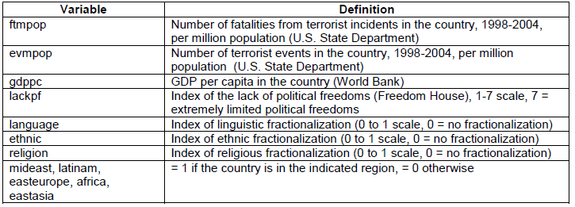

Data Description

### Part 1 Preliminary Data Analysis

#### Reading the Data File

```r
### Loading the data
terror_data <- read_dta("S:\\Baruch\\ECO 4000\\Spring2022\\Practice Problems\\Computer_Assignment\\terrorism.dta")
```

#### Data Preparation

```r
terror_data<- terror_data%>%
  filter(!is.na(gdppc) & ftmpop > 0 ) ## Preparing the sample for analysis

terror_data_new = terror_data %>%
  mutate(lnftmpop = log(ftmpop), lngdppc = log(gdppc)) ## Creating new variables
```

#### Plotting the data using ggplot2

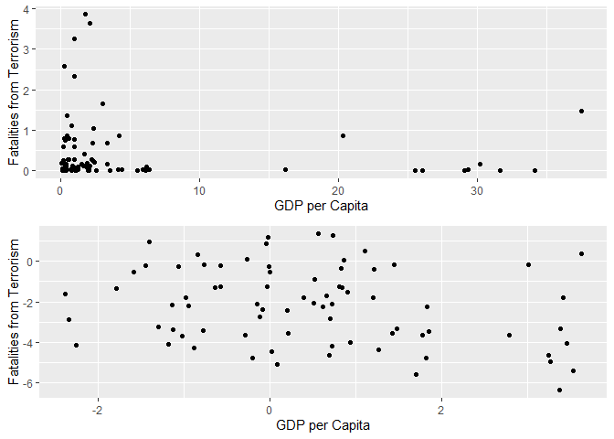

```r
p1 <- ggplot(terror_data_new, aes(x = gdppc, y = ftmpop))+
  geom_point()+
  xlab("GDP per Capita")+
  ylab("Fatalities from Terrorism")

p2 <- ggplot(terror_data_new, aes(x = lngdppc, y = lnftmpop))+
  geom_point()+
  xlab("GDP per Capita")+
  ylab("Fatalities from Terrorism")

gridExtra::grid.arrange(p1,p2, ncol = 1)
```

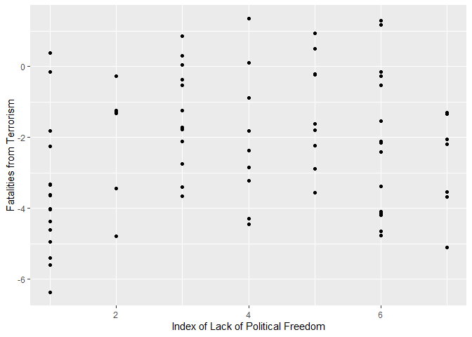

```r
p3 <-ggplot(terror_data_new, aes(x = lackpf, y = lnftmpop))+
  geom_point()+
  xlab("Index of Lack of Political Freedom")+
  ylab("Fatalities from Terrorism")
p3
```

4. The relation in the *ftmpop* – *gdppc* scatterplot looks highly nonlinear, like a hyperbola but with a couple of outliers. Taking logs of both variables makes the hyperbolic-type relation look much more like a scatter with a (weak) linear relation, the sort of thing that can be well handled by conventional multiple linear regression methods.

### Part 2 Regression Results

```r
terror_data_new = terror_data_new%>%
  mutate(lngdppc2 = (lngdppc)^2, lackpf2 = (lackpf)^2) ## Creating required variables

model_1 <- lm(data = terror_data_new, lnftmpop ~ lngdppc)
model_2 <- lm(data = terror_data_new, lnftmpop ~ lngdppc + lackpf)
model_3 <- lm(data = terror_data_new, lnftmpop ~ lngdppc + lngdppc2 + lackpf + lackpf2)
model_4 <- lm(data = terror_data_new, lnftmpop ~ lngdppc + lackpf + lackpf2 + ethnic + religion)
model_5 <- lm(data = terror_data_new, lnftmpop ~ lngdppc + lackpf + lackpf2 + ethnic + religion + mideast + latinam + easteurope + eastasia + africa)
stargazer(model_1, model_2,model_3,model_4,model_5,type = "html",dep.var.labels   = "Fatalities from Terrorism per Population", title = "Determinants of Terrorism", style = "qje",notes.append = FALSE,notes = c("<sup>&sstarf;</sup>p<0.1; <sup>&sstarf;&sstarf;</sup>p<0.05; <sup>&sstarf;&sstarf;&sstarf;</sup>p<0.01"))
```

**Determinants of Terrorism**

|  | Fatalities from Terrorism per Population |  |  |  |  |
| --- | --- | --- | --- | --- | --- |
|  | (1) | (2) | (3) | (4) | (5) |
| lngdppc | -0.312** | -0.279 | 0.057 | 0.047 | -0.065 |
|  | (0.141) | (0.196) | (0.222) | (0.229) | (0.297) |
| lngdppc2 |  |  | -0.034 |  |  |
|  |  |  | (0.082) |  |  |
| lackpf |  | 0.036 | 1.651** | 1.466** | 1.691** |
|  |  | (0.144) | (0.648) | (0.612) | (0.705) |
| lackpf2 |  |  | -0.194** | -0.170** | -0.199** |
|  |  |  | (0.074) | (0.071) | (0.081) |
| ethnic |  |  |  | 0.656 | 0.878 |
|  |  |  |  | (0.985) | (1.082) |
| religion |  |  |  | -1.243 | -1.573 |
|  |  |  |  | (0.922) | (1.177) |
| mideast |  |  |  |  | -1.119 |
|  |  |  |  |  | (1.227) |
| latinam |  |  |  |  | -1.707 |
|  |  |  |  |  | (1.070) |
| easteurope |  |  |  |  | -1.072 |
|  |  |  |  |  | (0.972) |
| eastasia |  |  |  |  | -1.004 |
|  |  |  |  |  | (1.024) |
| africa |  |  |  |  | -1.275 |
|  |  |  |  |  | (1.277) |
| Constant | -2.048*** | -2.201*** | -4.813*** | -4.431*** | -3.579** |
|  | (0.222) | (0.655) | (1.314) | (1.318) | (1.560) |
| *N* | 76 | 76 | 76 | 74 | 74 |
| R<sup>2</sup> | 0.062 | 0.063 | 0.170 | 0.179 | 0.212 |
| Adjusted R<sup>2</sup> | 0.049 | 0.037 | 0.123 | 0.119 | 0.087 |
| Residual Std. Error | 1.843 (df = 74) | 1.855 (df = 73) | 1.770 (df = 71) | 1.767 (df = 68) | 1.799 (df = 63) |
| F Statistic | 4.881** (df = 1; 74) | 2.440* (df = 2; 73) | 3.625*** (df = 4; 71) | 2.969** (df = 5; 68) | 1.696 (df = 10; 63) |
| *Notes:* | <sup>⋆</sup>p<0.1; <sup>⋆⋆</sup>p<0.05; <sup>⋆⋆⋆</sup>p<0.01 |  |  |  |  |

### Part 3 Hypothesis Testing and Result Interpretation

1. $$H_{0} : \beta_{lngdppc} = 0$$
   $$H_{1} : \beta_{lngdppc} \neq
   0$$

$t = -2.21$. Hence,so $|t_{calculated}| > |t_{critical}|$,$|-2.21| > |1.96|$. The hypothesis is rejected at the 5 % significance level. The estimated coefficient, $-.312$, means that a 1 % increase in GDP per capita is associated with a 0.312 % decrease in terrorist fatalities.

2. F = 0.096 with p-value = 0.9086. So, the hypothesis that both coefficients are zero (holding constant lackpf and lackpf2) is not rejected at the 5% (or 10%) significance level.

```r
linearHypothesis(model_3, c("lngdppc = 0","lngdppc2 = 0")) ## Homoskedastic Errors
```

```
## Linear hypothesis test
##
## Hypothesis:
## lngdppc = 0
## lngdppc2 = 0
##
## Model 1: restricted model
## Model 2: lnftmpop ~ lngdppc + lngdppc2 + lackpf + lackpf2
##
##   Res.Df    RSS Df Sum of Sq      F Pr(>F)
## 1     73 223.12
## 2     71 222.52  2   0.60134 0.0959 0.9086
```

```r
linearHypothesis(model_3, c("lngdppc = 0","lngdppc2 = 0"),white.adjust = "hc1") ## heteroskedasticity robust standard errors
```

```
## Linear hypothesis test
##
## Hypothesis:
## lngdppc = 0
## lngdppc2 = 0
##
## Model 1: restricted model
## Model 2: lnftmpop ~ lngdppc + lngdppc2 + lackpf + lackpf2
##
## Note: Coefficient covariance matrix supplied.
##
##   Res.Df Df      F Pr(>F)
## 1     73
## 2     71  2 0.1061 0.8995
```

3. The results in **(a)** do not control for *lackpf*, whereas the results in **(b)** do (they control for a quadratic in lackpf). The explanation is straight OV bias – in **(a)**, lngdppc is picking up the effect of *lackpf*, with which it is correlated, and which is a determinant of *lnftmpop*.
4. F = 0.6576 with p-value = 0.0.6237, so the hypothesis is not rejected at the 5% (or 10%) significance level. The number of restrictions is the number of coefficients that are zero under the null, here q = 4 (coefficients on latinam, easteurope, africa, eastasia). The 5% critical value of the $F_{4,\infty}$ distribution is 2.37.

```r
linearHypothesis(model_5, c("latinam = 0","easteurope = 0","eastasia = 0","africa = 0")) ## Homoskedastic Errors
```

```
## Linear hypothesis test
##
## Hypothesis:
## latinam = 0
## easteurope = 0
## eastasia = 0
## africa = 0
##
## Model 1: restricted model
## Model 2: lnftmpop ~ lngdppc + lackpf + lackpf2 + ethnic + religion + mideast +
##     latinam + easteurope + eastasia + africa
##
##   Res.Df    RSS Df Sum of Sq      F Pr(>F)
## 1     67 212.38
## 2     63 203.87  4    8.5121 0.6576 0.6237
```

```r
linearHypothesis(model_5, c("latinam = 0","easteurope = 0","eastasia = 0","africa = 0"),white.adjust = "hc1") ## heteroskedasticity robust standard errors
```

```
## Linear hypothesis test
##
## Hypothesis:
## latinam = 0
## easteurope = 0
## eastasia = 0
## africa = 0
##
## Model 1: restricted model
## Model 2: lnftmpop ~ lngdppc + lackpf + lackpf2 + ethnic + religion + mideast +
##     latinam + easteurope + eastasia + africa
##
## Note: Coefficient covariance matrix supplied.
##
##   Res.Df Df      F Pr(>F)
## 1     67
## 2     63  4 0.8085 0.5244
```